# Assignment #2 for DSSI

B05102074 何青儒 Ho Ching Ruu

2018-10-01

# MENU

- R01_2 vector
  - Practice I
  - Practice II
- R01_4 dataframe tp theft
  - Practice I
  - Practice II
- R01_5 prac load and summarize tweet data
  - Question I
  - Question II

# R01_2 vector

### Practice I

0. Generate the origin data

```r
# Generate x.a with 1000 numbers with mean = 1 sderr = 10
x.a <- rnorm(1000, 1, 10)
```

1. Filter out extreme values out of two standard deviations

```r
# Use subset() to filter out the value we do not need
# Put the value that we need into xfilter
xfilter <- subset(x.a, x.a <= mean(x.a) + 2*sd(x.a) & x.a >= mean(x.a) - 2*sd(x.a))
```

2. Plotting the distribution of the remaining vector x.a

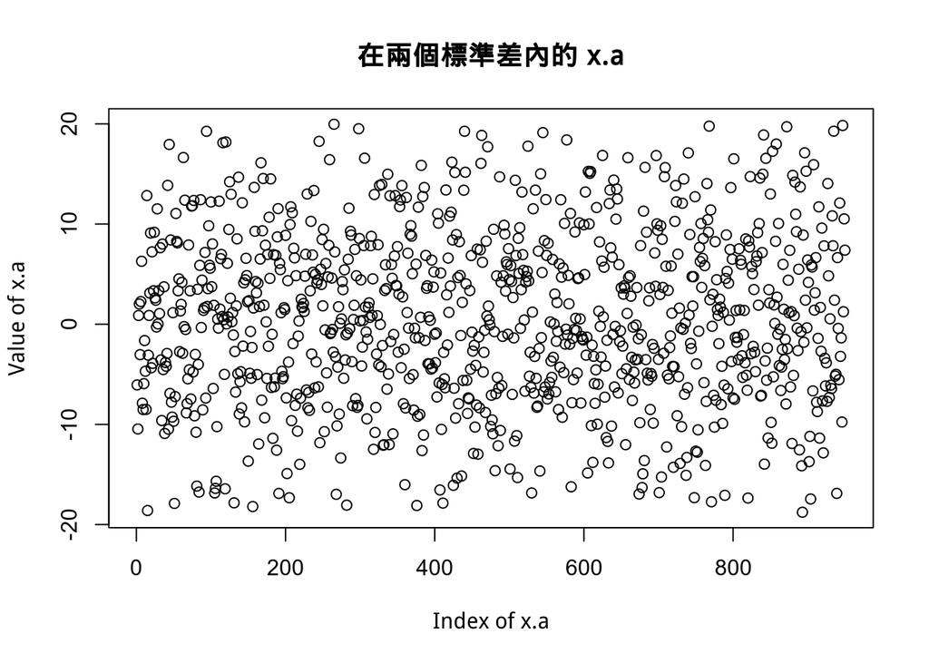

```r
# Scatter plot
plot(xfilter, main = "在兩個標準差內的 x.a", xlab = "Index of x.a", ylab = "Value of x.a")
```

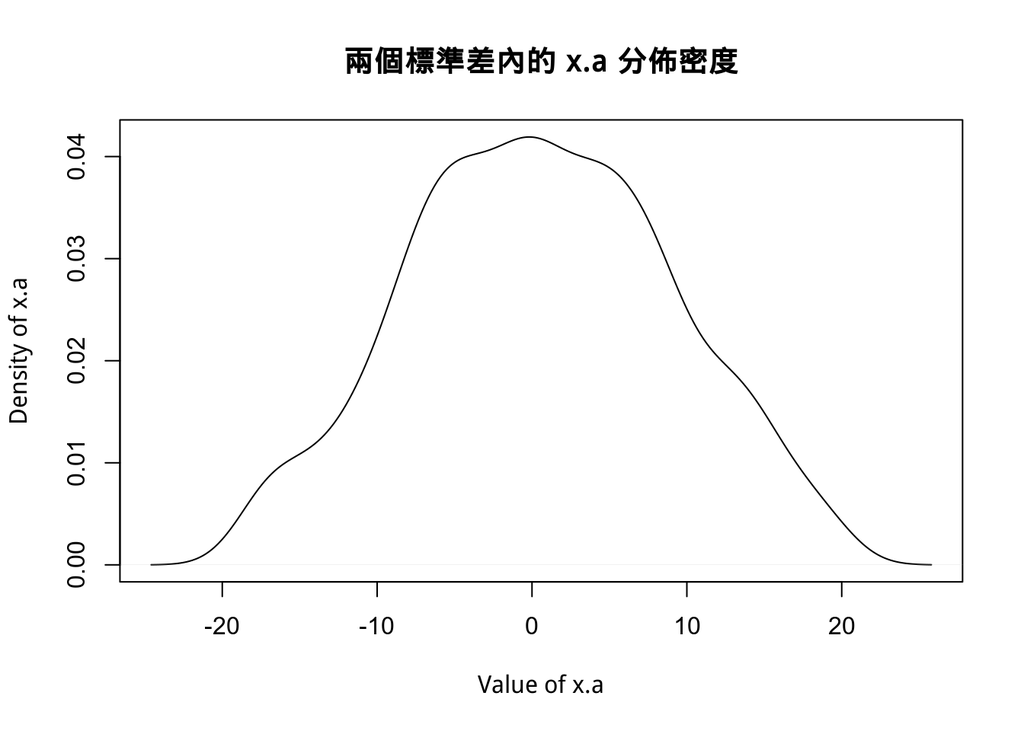

```r
# Density plot
plot(density(xfilter), main = "兩個標準差內的 x.a 分佈密度", xlab = "Value of x.a", ylab = "Density of x.a")
```

3. Calculate the 25%, 50% and 75% quantile of vector x.a.

```r
# Generate a vector named Qan to save quantile of xfilter
Qan <- quantile(xfilter, probs=seq(0, 1, 0.25))

# Show quantile of xfilter
Qan
```

```
##         0%        25%        50%        75%       100%
## -18.768525  -5.509159   0.441764   6.641543  19.963724
```

4. Get the number between 25% to 75% and assign to x.a1

```r
# Use double [] ([[i]]) for the named numeric vector Qan
x.a1 <- subset(xfilter, xfilter >= Qan[["25%"]] & xfilter <= Qan[["75%"]] )
```

5. Plotting x.a1

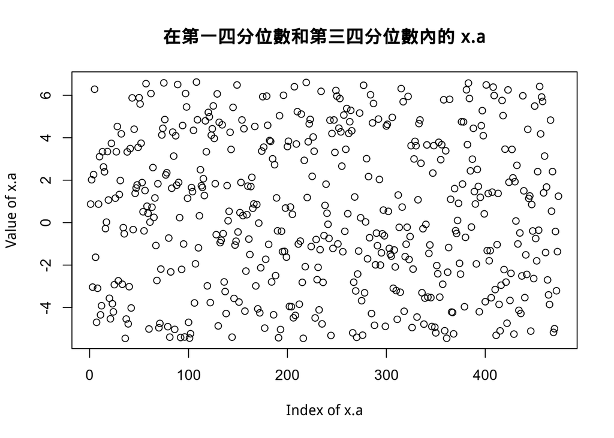

```r
# Scatter plot
plot(x.a1, main = "在第一四分位數和第三四分位數內的 x.a", xlab = "Index of x.a", ylab = "Value of x.a")
```

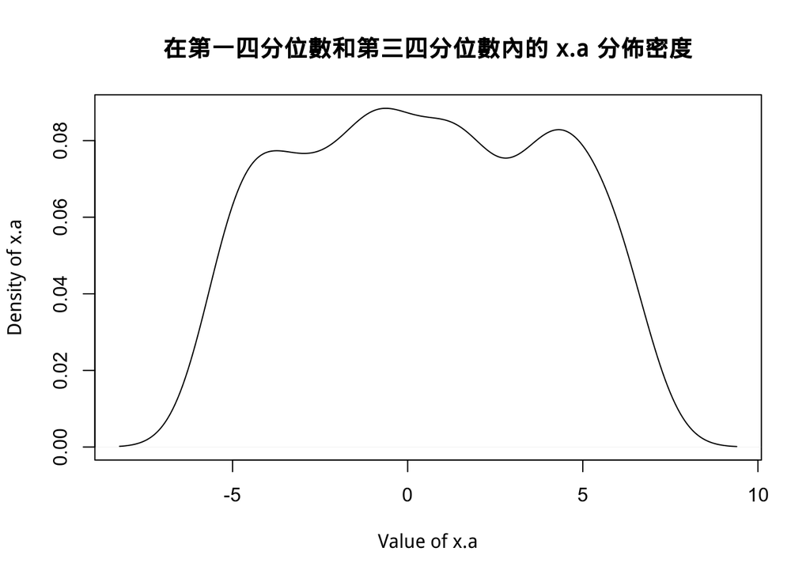

```r
# Density plot
plot(density(x.a1), main = "在第一四分位數和第三四分位數內的 x.a 分佈密度", xlab = "Value of x.a", ylab = "Density of x.a")
```

### Practice II

**Accessing characters**

1. Generate the origin data

```r
x.b <- c("a", "b", "c", "d", "e", "f", "g", "h", "i", "j", "k")
```

2. Get only elements at odd positions and assign to x.b1

```r
# Only the elements at odd position will be TRUE and save to x.b1
# Elements at even position will be FALSE and be ignored
x.b1 <- x.b[c(TRUE,FALSE)]
```

3. Truncate the first 2 elements and the last 2 elements and assign to x.b2

```r
n <- length(x.b1)
# Defined n be the length of x.b

x.b2 <- x.b1[3:(n-2)]
# Only the third element to the lsat 2 element will assign to x.b2
```

4. Result

```r
# Show each vector
x.b
```

```
##  [1] "a" "b" "c" "d" "e" "f" "g" "h" "i" "j" "k"
```

```r
x.b1
```

```
## [1] "a" "c" "e" "g" "i" "k"
```

```r
x.b2
```

```
## [1] "e" "g"
```

# R01_4 dataframe tp theft

Something we need to command first.

```r
url <- "http://data.taipei/opendata/datalist/datasetMeta/download?id=68785231-d6c5-47a1-b001-77eec70bec02&rid=34a4a431-f04d-474a-8e72-8d3f586db3df"
df <- read.csv(url, fileEncoding = "big5")
df$time <- substr(df$發生時段, 1, 2)
df$region <- substr(df$發生.現.地點, 4, 5)
```

### Practice I

**Using mosaicplot() to check what happens if you swap the time and region in tapply()**

> Befor (the original method and mosaicplot)

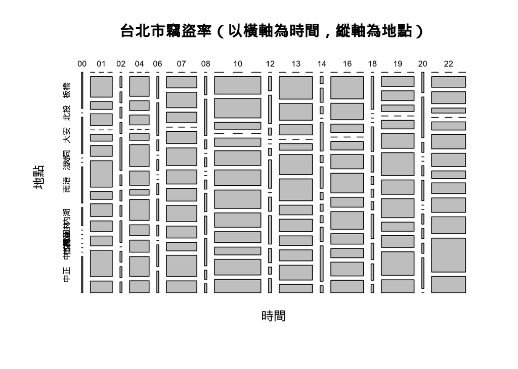

```r
res <- tapply(df$編號, list(df$time, df$region), length, default = 0)
mosaicplot(res, main = "台北市竊盜率（以橫軸為時間，縱軸為地點）", xlab = "時間", ylab = "地點")
```

> After (swap the time and region)

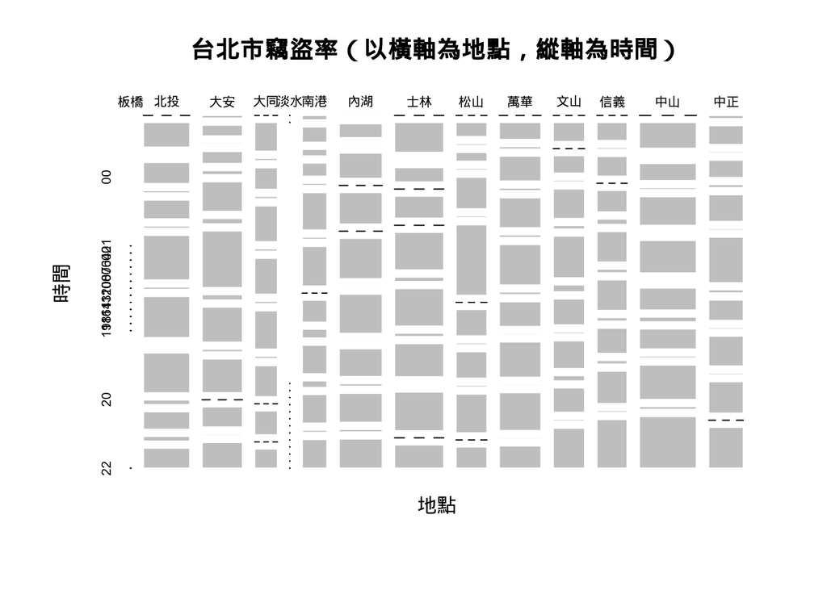

```r
res_swap <- tapply(df$編號, list(df$region, df$time), length, default = 0)
mosaicplot(res_swap, border=0, main = "台北市竊盜率（以橫軸為地點，縱軸為時間）", ylab = "時間", xlab = "地點")
```

We can observe that the x-axis and y-axis are be reversed.

### Practice II

**Does it possible to extract month by substr()?**

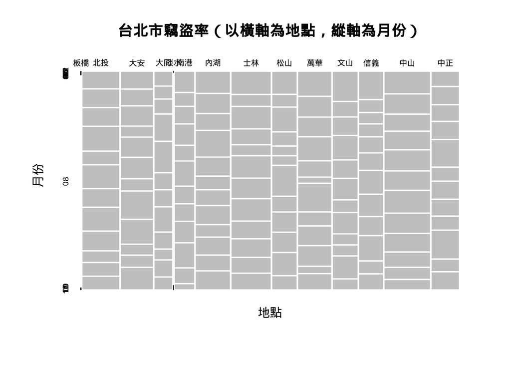

```r
# Use stringr function
library("stringr")
x <- df$發生.現.日期

# Month
df$month <- str_sub(x, -4, -3)

res2 <- tapply(df$編號, list(df$month, df$region), length,default = 0)
res2 <- tapply(df$編號, list(df$region, df$month), length,default = 0)

# Mosaicplot
mosaicplot(res2, border=0, off = 3, main = "台北市竊盜率（以橫軸為地點，縱軸為月份）", ylab = "月份", xlab = "地點")
```

# R01_5 prac load and summarize tweet data

### Question I

**當現在載入了他人所蒐集且開放的Trump’s tweets後，你會形成什麼樣的假設？你會探討什麼問題？**

```
不得不說 Trump 一直以來都超愛用 Twitter，從大事小事私事國家大事都曾用 Twitter 發言，甚至常被說是用 Twitter 來治國。

而 Trump 常用 Twitter 的原因有很多種說法，其中我覺得最有道理的一種說法是 Trump 認為比起在白宮或是國會開記者會說著無趣又正式的官方新聞稿，Twitter 這種每篇不到 200 字的即興小短文，更能讓喜歡的人和媒體知道他在講什麼、想什麼。

事實上，當我們回頭審視 Trump 在選前以的摧票演講及選後的上任演講時，我們不難發現他都用那些簡單不生澀、接近庶民、連國小生都廳的懂的字詞來組織他的演講內容。一方面是他本來就不是玩政治出生，那些政府或政客之間常用的 doublespeak word 對他而言根本不了解；而令一方面，使用接近庶民的語言，也能拉近他和選民之間的距離，形塑一種親切的感覺。

透過他 Twitter 每則推文所使用的字數，以及每則推文所得到的愛心數，或許我們可以迴歸出一個「當一篇貼文約有多少字時，一般人會選擇停下滑動態的手指，觀看整篇貼文，然後按下愛心」。

畢竟如果一篇推文太短，那我們在滑閱動態的時候很容易就會忽略掉；反之，當一篇推文太長時，我們也往往覺得太冗太多字不想看然後直接滑掉。
```

### Question II

**除了想像這份資料可以做什麼分析外，請嘗試執行下列程式碼。請問，下列程式碼的執行結果分別可以回答什麼樣的問題？**

#### begin

1. 從 varianceexplained.org 抓下 trump_tweets 的 data.frame

```r
load(url("http://varianceexplained.org/files/trump_tweets_df.rda"))
df <- trump_tweets_df
```

```r
filter.df <- df[df$favoriteCount > mean(df$favoriteCount) +2*sd (df$favoriteCount),]
# View(fliter.df)
```

```r
filter.df2 <- df[df$retweetCount > mean(df$retweetCount) + 2* sd (df$retweetCount),]
# View(fliter.df2)
```

```r
order.df <- df[order(df$favoriteCount, decreasing = TRUE),]
# View(order.df[1:10,])
```

5. 上面 2. 到 4. 的步驟，也可以用 Pipeline 運算子進行

```r
# pipeline要從tidyverse函式庫呼叫
# Ubuntu/Debian下要追加以下lib才能安裝tidyverse
# curl: $sudo apt-get install curl
# libssl-dev: $sudo apt-get install libssl-dev
# libcurl: $sudo apt-get install libcurl4-openssl-dev
# xml2: $sudo apt-get install libxml2-dev
install.packages("tidyverse")
# 引入
library("tidyverse")
# 效果同步驟2
filter.df3 <- df %>%
    filter(df$favoriteCount > mean(df$favoriteCount) + 2*sd(df$favoriteCount))

# 效果同步驟3
filter.df4 <- df %>%
    arrange(-favoriteCount)
```

#### plot histogram

- What is histogram? What is density function?

  Histogram = **直條圖**
1. 依愛心數量生成直條圖

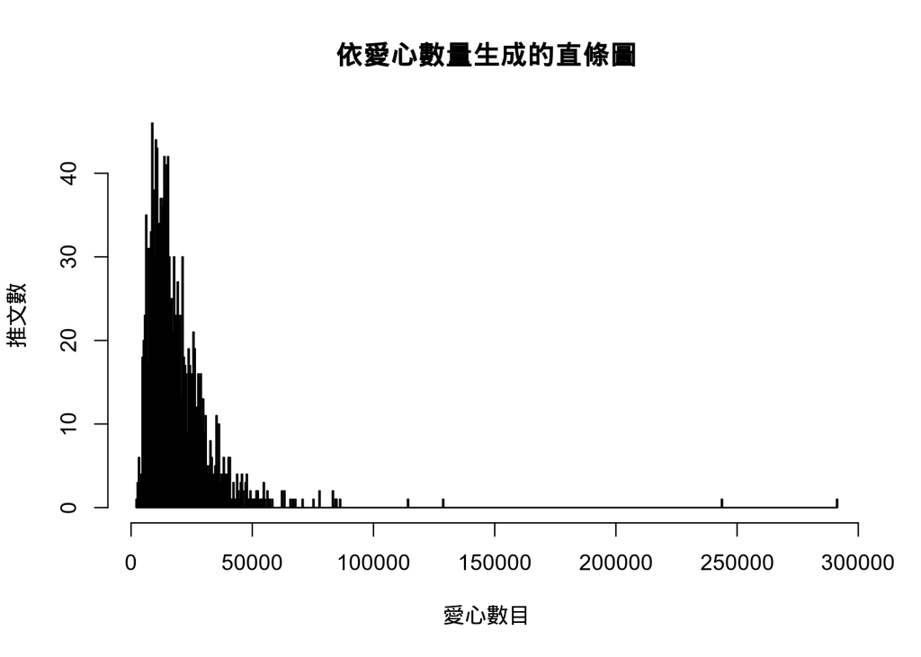

```r
# histogram
hist(df$favoriteCount, breaks = 1000, main = "依愛心數量生成的直條圖", xlab = "愛心數目", ylab = "推文數")
```

2. 依每篇文字字數生成直條圖

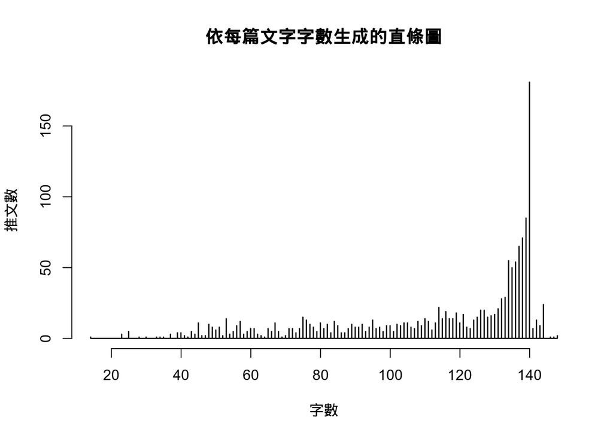

```r
# nchar : Count the Number of Characters
df$nchar <-nchar (df$text)

# histogram
hist(df$nchar, breaks= 1000, main = "依每篇文字字數生成的直條圖", xlab = "字數", ylab = "推文數")
```

事實上，在 2017 年前，推特每則推文不能超過 140 字，爾後才開放到 280 字

#### take a glance on the data

```r
# View(order.df[ ,c(1,3,5,8,10,12)])
# View(order.df[, c("text","favoriteCount")])

# 查看整個df
View(df)
# 預覽前幾筆df
head(df)
```

```
## # A tibble: 6 x 17
##   text  favorited favoriteCount replyToSN created             truncated
##   <chr> <lgl>             <dbl> <chr>     <dttm>              <lgl>
## 1 My e… FALSE              9214 <NA>      2016-08-08 15:20:44 FALSE
## 2 Join… FALSE              6981 <NA>      2016-08-08 13:28:20 FALSE
## 3 "#IC… FALSE             15724 <NA>      2016-08-08 00:05:54 FALSE
## 4 Mich… FALSE             19837 <NA>      2016-08-07 23:09:08 FALSE
## 5 "The… FALSE             34051 <NA>      2016-08-07 21:31:46 FALSE
## 6 I se… FALSE             29831 <NA>      2016-08-07 13:49:29 FALSE
## # ... with 11 more variables: replyToSID <lgl>, id <chr>,
## #   replyToUID <chr>, statusSource <chr>, screenName <chr>,
## #   retweetCount <dbl>, isRetweet <lgl>, retweeted <lgl>, longitude <chr>,
## #   latitude <chr>, nchar <int>
```

```r
class(df)
```

```
## [1] "tbl_df"     "tbl"        "data.frame"
```

```r
str(df)
```

```
## Classes 'tbl_df', 'tbl' and 'data.frame':    1512 obs. of  17 variables:
##  $ text         : chr  "My economic policy speech will be carried live at 12:15 P.M. Enjoy!" "Join me in Fayetteville, North Carolina tomorrow evening at 6pm. Tickets now available at: https://t.co/Z80d4MYIg8" "#ICYMI: \"Will Media Apologize to Trump?\" https://t.co/ia7rKBmioA" "Michael Morell, t…
##  $ favorited    : logi  FALSE FALSE FALSE FALSE FALSE FALSE ...
##  $ favoriteCount: num  9214 6981 15724 19837 34051 ...
##  $ replyToSN    : chr  NA NA NA NA ...
##  $ created      : POSIXct, format: "2016-08-08 15:20:44" "2016-08-08 13:28:20" ...
##  $ truncated    : logi  FALSE FALSE FALSE FALSE FALSE FALSE ...
##  $ replyToSID   : logi  NA NA NA NA NA NA ...
##  $ id           : chr  "762669882571980801" "762641595439190016" "762439658911338496" "762425371874557952" ...
##  $ replyToUID   : chr  NA NA NA NA ...
##  $ statusSource : chr  "<a href=\"http://twitter.com/download/android\" rel=\"nofollow\">Twitter for Android</a>" "<a href=\"http://twitter.com/download/iphone\" rel=\"nofollow\">Twitter for iPhone</a>" "<a href=\"http://twitter.com/download/iphone\" rel=\"nofollow\">Twitter for iPhone</a>" "<a h…
##  $ screenName   : chr  "realDonaldTrump" "realDonaldTrump" "realDonaldTrump" "realDonaldTrump" ...
##  $ retweetCount : num  3107 2390 6691 6402 11717 ...
##  $ isRetweet    : logi  FALSE FALSE FALSE FALSE FALSE FALSE ...
##  $ retweeted    : logi  FALSE FALSE FALSE FALSE FALSE FALSE ...
##  $ longitude    : chr  NA NA NA NA ...
##  $ latitude     : chr  NA NA NA NA ...
##  $ nchar        : int  67 114 64 134 135 138 77 92 137 91 ...
```

```r
class(df$text)
```

```
## [1] "character"
```

```r
class(df$truncated)
```

```
## [1] "logical"
```

```r
df$truncated
```

[output not shown]

[output cut: 123 more lines]

```r
class(df$favoriteCount)
```

```
## [1] "numeric"
```

```r
class(df)
```

```
## [1] "tbl_df"     "tbl"        "data.frame"
```

```r
mode(df)
```

```
## [1] "list"
```

從前面的命題，以及上面的程式碼，我們還沒辦法給出兩者之間的關係。